# PROJECT - NEURAL NETWORKS

```
                                                                                    By: Aryan Jain
```

## March 2021

**Learning Objectives:**

- `Hands on designing, training, testing and tuning a handmade a deep learning neural network.`
- `Implementing a neural network as a classifier and a regressors on the same data.`
- `Implementing a neural network image classifier.`
- `Working with images and concepts of computer vision on how a model can be trained using images as a data source.`
- `Implementing a working GUI`
- `Hands on storing the best model and its weights for future usage avoiding the need to retraining the model for future.`

# Part 1

#### SUMMARY

**Context:** A communications equipment manufacturing company has a product which is responsible for emitting informative signals. Company wants to build a machine learning model which can help the company to predict the equipment’s signal quality using various parameters.

**Data Description:**  
The data set contains information on various signal tests performed:

```
• Parameters: Various measurable signal parameters
• Signal_Quality: Final signal strength or quality
```

**Domain:** Electronics and Telecommunication

**Objectives:** The need is to build a regressor which can use these parameters to determine the signal strength or quality

**Key Tasks:**

- Import data
- Data analysis & visualisation
- Design, train, tune and test a neural network regressor
- Design, train, tune and test a neural network classifier
- Design, train, tune and test a neural network image classifier
- Plot the training loss, validation loss vs number of epochs and training accuracy, validation accuracy vs number of epochs plot
- Pickle the model for future use

### Importing Libraries

#### Libraries for Data Management and Vizualization

```python
import pandas as pd
import numpy as np
import matplotlib.pyplot as plt
%matplotlib inline
import seaborn as sns
```

#### Libraries to pre-process the data

```python
from sklearn.preprocessing import LabelEncoder
from keras.utils import np_utils
from imblearn.over_sampling import SMOTE
```

#### Libraries to create and run the model

```python
from tensorflow.keras.models import Sequential
from tensorflow.keras.layers import Dense
from tensorflow.keras.layers import BatchNormalization
from tensorflow.keras.layers import Activation
from tensorflow.keras.layers import Dropout
from sklearn.model_selection import train_test_split
from tensorflow.keras import optimizers
```

#### Library to pickle models

```python
from keras.models import model_from_json
```

#### Libraries for NN GUI

```python
import tkinter as tk
from tkinter import ttk
```

#### Miscellaneous Libraries

```python
import datetime
import h5py
from tensorflow import keras
import re
```

```python
# Using this to measure total execution time, just for curiosity
now = datetime.datetime.now()
print(f"Starting Time: {now.hour}:{now.minute}")
```

```
Starting Time: 12:24
```

### PART 1

#### Import data & Inspect

```python
# Import data from csv file

df = pd.read_csv("Part- 1,2&3 - Signal.csv")
```

```python
# Display first 5 rows

df.head()
```

|  | Parameter 1 | Parameter 2 | Parameter 3 | Parameter 4 | Parameter 5 | Parameter 6 | Parameter 7 | Parameter 8 | Parameter 9 | Parameter 10 | Parameter 11 | Signal_Strength |
| --- | --- | --- | --- | --- | --- | --- | --- | --- | --- | --- | --- | --- |
| 0 | 7.4 | 0.70 | 0.00 | 1.9 | 0.076 | 11.0 | 34.0 | 0.9978 | 3.51 | 0.56 | 9.4 | 5 |
| 1 | 7.8 | 0.88 | 0.00 | 2.6 | 0.098 | 25.0 | 67.0 | 0.9968 | 3.20 | 0.68 | 9.8 | 5 |
| 2 | 7.8 | 0.76 | 0.04 | 2.3 | 0.092 | 15.0 | 54.0 | 0.9970 | 3.26 | 0.65 | 9.8 | 5 |
| 3 | 11.2 | 0.28 | 0.56 | 1.9 | 0.075 | 17.0 | 60.0 | 0.9980 | 3.16 | 0.58 | 9.8 | 6 |
| 4 | 7.4 | 0.70 | 0.00 | 1.9 | 0.076 | 11.0 | 34.0 | 0.9978 | 3.51 | 0.56 | 9.4 | 5 |

```python
# Let's check the shape of the dataset
print(f"This dataset has {df.shape[0]} rows and {df.shape[1]} columns")
```

```
This dataset has 1599 rows and 12 columns
```

```python
# Looking at the datatypes of each column
df.dtypes
```

```
Parameter 1        float64
Parameter 2        float64
Parameter 3        float64
Parameter 4        float64
Parameter 5        float64
Parameter 6        float64
Parameter 7        float64
Parameter 8        float64
Parameter 9        float64
Parameter 10       float64
Parameter 11       float64
Signal_Strength      int64
dtype: object
```

```python
# Checking for any misssing values
df.isnull().any().any()
```

```
False
```

**`OBSERVATIONS:`**

- `Number of features / columns = 12`
- `Number of records / records = 1599`
- `The dataset represents measurable signal parameters, and final signal strength`
- `All features are numeric`
- `There are no missing values`
- `I will not consider dropping any features as they all are parameters for the features so I think there won't be much multicolinearity and they will and help predict signal strength. However, I will validate during visual analysis in this notebook`

#### Data Analysis and Visualisation

```python
# Let's run few steps, I will note down observations together
```

```python
# Basic stats for Numerical attributes, including Five point summary

df.describe()
```

|  | Parameter 1 | Parameter 2 | Parameter 3 | Parameter 4 | Parameter 5 | Parameter 6 | Parameter 7 | Parameter 8 | Parameter 9 | Parameter 10 | Parameter 11 | Signal_Strength |
| --- | --- | --- | --- | --- | --- | --- | --- | --- | --- | --- | --- | --- |
| count | 1599.000000 | 1599.000000 | 1599.000000 | 1599.000000 | 1599.000000 | 1599.000000 | 1599.000000 | 1599.000000 | 1599.000000 | 1599.000000 | 1599.000000 | 1599.000000 |
| mean | 8.319637 | 0.527821 | 0.270976 | 2.538806 | 0.087467 | 15.874922 | 46.467792 | 0.996747 | 3.311113 | 0.658149 | 10.422983 | 5.636023 |
| std | 1.741096 | 0.179060 | 0.194801 | 1.409928 | 0.047065 | 10.460157 | 32.895324 | 0.001887 | 0.154386 | 0.169507 | 1.065668 | 0.807569 |
| min | 4.600000 | 0.120000 | 0.000000 | 0.900000 | 0.012000 | 1.000000 | 6.000000 | 0.990070 | 2.740000 | 0.330000 | 8.400000 | 3.000000 |
| 25% | 7.100000 | 0.390000 | 0.090000 | 1.900000 | 0.070000 | 7.000000 | 22.000000 | 0.995600 | 3.210000 | 0.550000 | 9.500000 | 5.000000 |
| 50% | 7.900000 | 0.520000 | 0.260000 | 2.200000 | 0.079000 | 14.000000 | 38.000000 | 0.996750 | 3.310000 | 0.620000 | 10.200000 | 6.000000 |
| 75% | 9.200000 | 0.640000 | 0.420000 | 2.600000 | 0.090000 | 21.000000 | 62.000000 | 0.997835 | 3.400000 | 0.730000 | 11.100000 | 6.000000 |
| max | 15.900000 | 1.580000 | 1.000000 | 15.500000 | 0.611000 | 72.000000 | 289.000000 | 1.003690 | 4.010000 | 2.000000 | 14.900000 | 8.000000 |

```python
# Let's check cardinality of Signal Strength field

df['Signal_Strength'].nunique()
```

```
6
```

```python
# Unique values in Signal Strength field

df.Signal_Strength.unique()
```

```
array([5, 6, 7, 4, 8, 3])
```

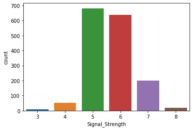

```python
X = df.drop("Signal_Strength", axis=1)
y = df['Signal_Strength']

sns.countplot(x=y);
```

```python
# Let's take a closer look at Target attribute distribution

x_pct = pd.DataFrame((df['Signal_Strength'].value_counts(normalize = True)*100).round(2)).reset_index()
x_cnt = pd.DataFrame(df['Signal_Strength'].value_counts()).reset_index()
x_cnt_pct = pd.merge(x_pct, x_cnt, right_index=True, left_index=True)
x_cnt_pct.drop('index_y', inplace=True, axis=1)

x_cnt_pct.columns =["Signal_Strength","%", "Count"]
x_cnt_pct
```

|  | Signal_Strength | % | Count |
| --- | --- | --- | --- |
| 0 | 5 | 42.59 | 681 |
| 1 | 6 | 39.90 | 638 |
| 2 | 7 | 12.45 | 199 |
| 3 | 4 | 3.31 | 53 |
| 4 | 8 | 1.13 | 18 |
| 5 | 3 | 0.63 | 10 |

```python
# Getting an idea for the feature distribution

relation_df = df.copy()
for col in relation_df.columns[1:-1]:
    print(f"Distribution for {col}")
    fig=plt.figure(figsize=(12, 6))

    ax = fig.add_subplot(121)
    sns.distplot(relation_df);
    plt.show();
```

[output not shown]

```
Distribution for Parameter 2
```

```
Distribution for Parameter 3
```

```
Distribution for Parameter 4
```

```
Distribution for Parameter 5
```

```
Distribution for Parameter 6
```

```
Distribution for Parameter 7
```

```
Distribution for Parameter 8
```

```
Distribution for Parameter 9
```

```
Distribution for Parameter 10
```

```
Distribution for Parameter 11
```

**`OBSERVATIONS:`**

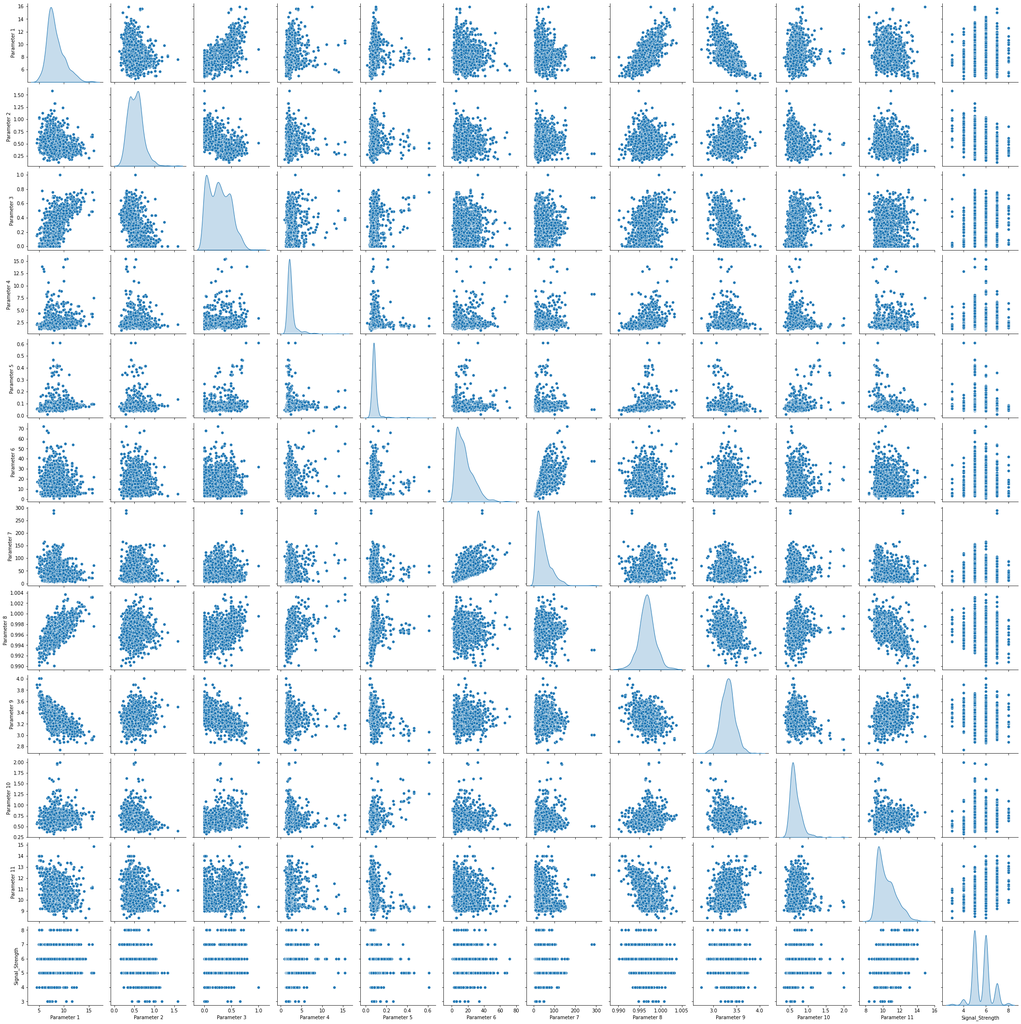

```python
# Visualize pairwise relationships & distribution, using pairplot

# This is to get a quick sense of strong relationship & correlation.

sns.pairplot(df, diag_kind='kde', palette='viridis');
```

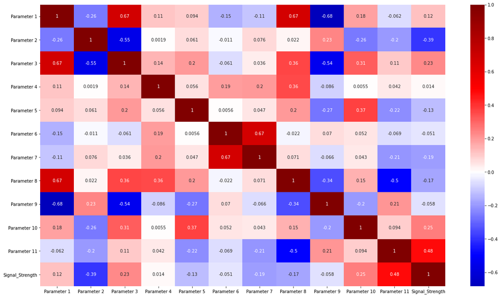

```python
# Let's visualize the pairwise correlation, for ease of understanding pairwise correlations.
# Will use threshold of 0.95 for correlations within independent variables
# And threshold of 0.01 for correlation between independent and target variable
plt.figure(figsize=(21, 12))
corr = df.corr()
sns.heatmap(corr, annot=True, fmt=".2g", cmap="seismic", center=0);
```

**Observations:**

- `There are no obvious high correlation within independent variables`
- `No correlation between independent and target variables are below set threshold`
- `Will not drop any features based on correlation`

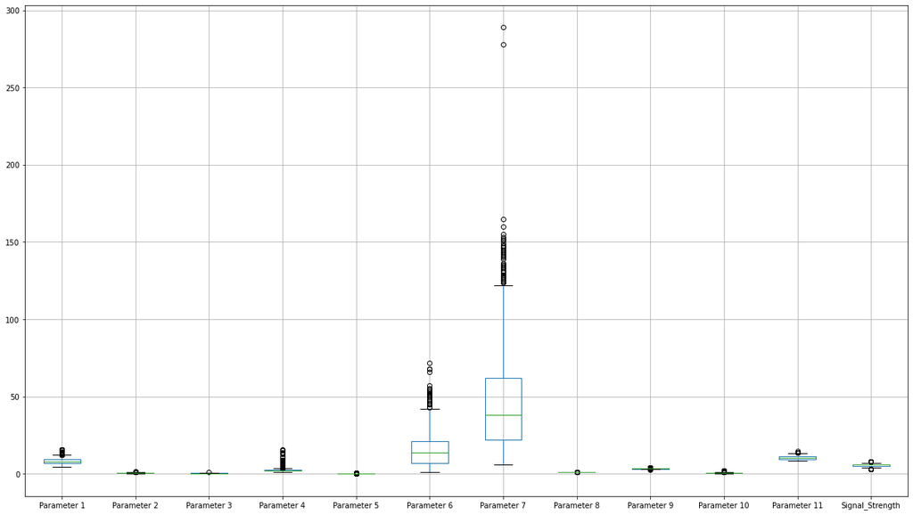

```python
# Box plot for a quick sense of outliers
plt.figure(figsize=(21,12))
df.boxplot();
```

**`Observations:`**

- `There seem to be many outliers for every variable`
- `Will not take any action on the outliers as I will be using batch normalization for my networks`
- `Batch Normalization helps reduce the effect that outliers have on networks by normalizing them`

```python
# Only feature engineering left is for oversampling (for classification / Part 2)
```